# Customer Churn Information

Churn- Whether the customer churned or not (Yes or No).Churn customer disconnected services Last Month.

# Demographic Statistics

1)customerID- Customer ID 2)gender- Whether the customer is a male or a female 3)SeniorCitizen- Whether the customer is a senior citizen or not (1, 0) 4)Partner- Whether the customer has a partner or not (Yes, No) 5)Dependents- Whether the customer has dependents or not (Yes, No)

# Customer Account INformation

1)tenure- Number of months the customer has stayed with the company 2)Contract- The contract term of the customer (Month-to-month, One year, Two year) 3)PaperlessBilling- Whether the customer has paperless billing or not (Yes, No) 4)PaymentMethod- The customer’s payment method (Electronic check, Mailed check, Bank transfer (automatic), Credit card (automatic)) 5)MonthlyCharges- The amount charged to the customer monthly 6)TotalCharges- The total amount charged to the customer

# Services Used By Customer

1)PhoneService- Whether the customer has a phone service or not (Yes, No) 2)MultipleLines- Whether the customer has multiple lines or not (Yes, No, No phone service) 3)InternetService- Customer’s internet service provider (DSL, Fiber optic, No) 4)OnlineSecurity- Whether the customer has online security or not (Yes, No, No internet service) 5)OnlineBackup- Whether the customer has online backup or not (Yes, No, No internet service) 6)DeviceProtection- Whether the customer has device protection or not (Yes, No, No internet service) 7)TechSupport- Whether the customer has tech support or not (Yes, No, No internet service) 8)StreamingTV- Whether the customer has streaming TV or not (Yes, No, No internet service) 9)StreamingMovies- Whether the customer has streaming movies or not (Yes, No, No internet service)

```python
 #importing libraries
import numpy as np
import pandas as pd
import matplotlib.pyplot as plt
import seaborn as sns
from sklearn.model_selection import train_test_split
from sklearn.linear_model import LinearRegression
from sklearn import metrics
import warnings
warnings.filterwarnings('ignore')
```

```python
# loading the data from csv file to a Pandas DataFrame
data=pd.read_csv("telecomdata.csv")
```

```python
df=data.copy()
```

```python
df.head()
```

|  | customerID | gender | SeniorCitizen | Partner | Dependents | tenure | PhoneService | MultipleLines | InternetService | OnlineSecurity | ... | DeviceProtection | TechSupport | StreamingTV | StreamingMovies | Contract | PaperlessBilling | PaymentMethod | MonthlyCharges | TotalCharges | Churn |
| --- | --- | --- | --- | --- | --- | --- | --- | --- | --- | --- | --- | --- | --- | --- | --- | --- | --- | --- | --- | --- | --- |
| 0 | 7590-VHVEG | Female | 0 | Yes | No | 1 | No | No phone service | DSL | No | ... | No | No | No | No | Month-to-month | Yes | Electronic check | 29.85 | 29.85 | No |
| 1 | 5575-GNVDE | Male | 0 | No | No | 34 | Yes | No | DSL | Yes | ... | Yes | No | No | No | One year | No | Mailed check | 56.95 | 1889.5 | No |
| 2 | 3668-QPYBK | Male | 0 | No | No | 2 | Yes | No | DSL | Yes | ... | No | No | No | No | Month-to-month | Yes | Mailed check | 53.85 | 108.15 | Yes |
| 3 | 7795-CFOCW | Male | 0 | No | No | 45 | No | No phone service | DSL | Yes | ... | Yes | Yes | No | No | One year | No | Bank transfer (automatic) | 42.30 | 1840.75 | No |
| 4 | 9237-HQITU | Female | 0 | No | No | 2 | Yes | No | Fiber optic | No | ... | No | No | No | No | Month-to-month | Yes | Electronic check | 70.70 | 151.65 | Yes |

5 rows × 21 columns

```python
df.tail()
```

|  | customerID | gender | SeniorCitizen | Partner | Dependents | tenure | PhoneService | MultipleLines | InternetService | OnlineSecurity | ... | DeviceProtection | TechSupport | StreamingTV | StreamingMovies | Contract | PaperlessBilling | PaymentMethod | MonthlyCharges | TotalCharges | Churn |
| --- | --- | --- | --- | --- | --- | --- | --- | --- | --- | --- | --- | --- | --- | --- | --- | --- | --- | --- | --- | --- | --- |
| 7038 | 6840-RESVB | Male | 0 | Yes | Yes | 24 | Yes | Yes | DSL | Yes | ... | Yes | Yes | Yes | Yes | One year | Yes | Mailed check | 84.80 | 1990.5 | No |
| 7039 | 2234-XADUH | Female | 0 | Yes | Yes | 72 | Yes | Yes | Fiber optic | No | ... | Yes | No | Yes | Yes | One year | Yes | Credit card (automatic) | 103.20 | 7362.9 | No |
| 7040 | 4801-JZAZL | Female | 0 | Yes | Yes | 11 | No | No phone service | DSL | Yes | ... | No | No | No | No | Month-to-month | Yes | Electronic check | 29.60 | 346.45 | No |
| 7041 | 8361-LTMKD | Male | 1 | Yes | No | 4 | Yes | Yes | Fiber optic | No | ... | No | No | No | No | Month-to-month | Yes | Mailed check | 74.40 | 306.6 | Yes |
| 7042 | 3186-AJIEK | Male | 0 | No | No | 66 | Yes | No | Fiber optic | Yes | ... | Yes | Yes | Yes | Yes | Two year | Yes | Bank transfer (automatic) | 105.65 | 6844.5 | No |

5 rows × 21 columns

```python
df.shape
```

```
(7043, 21)
```

```python
df.describe(include=object).T
```

|  | count | unique | top | freq |
| --- | --- | --- | --- | --- |
| customerID | 7043 | 7043 | 7590-VHVEG | 1 |
| gender | 7043 | 2 | Male | 3555 |
| Partner | 7043 | 2 | No | 3641 |
| Dependents | 7043 | 2 | No | 4933 |
| PhoneService | 7043 | 2 | Yes | 6361 |
| MultipleLines | 7043 | 3 | No | 3390 |
| InternetService | 7043 | 3 | Fiber optic | 3096 |
| OnlineSecurity | 7043 | 3 | No | 3498 |
| OnlineBackup | 7043 | 3 | No | 3088 |
| DeviceProtection | 7043 | 3 | No | 3095 |
| TechSupport | 7043 | 3 | No | 3473 |
| StreamingTV | 7043 | 3 | No | 2810 |
| StreamingMovies | 7043 | 3 | No | 2785 |
| Contract | 7043 | 3 | Month-to-month | 3875 |
| PaperlessBilling | 7043 | 2 | Yes | 4171 |
| PaymentMethod | 7043 | 4 | Electronic check | 2365 |
| TotalCharges | 7043 | 6531 |  | 11 |
| Churn | 7043 | 2 | No | 5174 |

```python
df.info()
```

```
<class 'pandas.core.frame.DataFrame'>
RangeIndex: 7043 entries, 0 to 7042
Data columns (total 21 columns):
 #   Column            Non-Null Count  Dtype
---  ------            --------------  -----
 0   customerID        7043 non-null   object
 1   gender            7043 non-null   object
 2   SeniorCitizen     7043 non-null   int64
 3   Partner           7043 non-null   object
 4   Dependents        7043 non-null   object
 5   tenure            7043 non-null   int64
 6   PhoneService      7043 non-null   object
 7   MultipleLines     7043 non-null   object
 8   InternetService   7043 non-null   object
 9   OnlineSecurity    7043 non-null   object
 10  OnlineBackup      7043 non-null   object
 11  DeviceProtection  7043 non-null   object
 12  TechSupport       7043 non-null   object
 13  StreamingTV       7043 non-null   object
 14  StreamingMovies   7043 non-null   object
 15  Contract          7043 non-null   object
 16  PaperlessBilling  7043 non-null   object
 17  PaymentMethod     7043 non-null   object
 18  MonthlyCharges    7043 non-null   float64
 19  TotalCharges      7043 non-null   object
 20  Churn             7043 non-null   object
dtypes: float64(1), int64(2), object(18)
memory usage: 1.1+ MB
```

```python
#TotalCharges should be a numeric feature but it has a dtype of object
df.TotalCharges = pd.to_numeric(df.TotalCharges,errors="coerce")
df.isnull().sum()
```

```
customerID           0
gender               0
SeniorCitizen        0
Partner              0
Dependents           0
tenure               0
PhoneService         0
MultipleLines        0
InternetService      0
OnlineSecurity       0
OnlineBackup         0
DeviceProtection     0
TechSupport          0
StreamingTV          0
StreamingMovies      0
Contract             0
PaperlessBilling     0
PaymentMethod        0
MonthlyCharges       0
TotalCharges        11
Churn                0
dtype: int64
```

```python
##Dropping rows containing NAN values from Totalcharges
df.dropna(inplace=True)
df.isnull().sum()
```

```
customerID          0
gender              0
SeniorCitizen       0
Partner             0
Dependents          0
tenure              0
PhoneService        0
MultipleLines       0
InternetService     0
OnlineSecurity      0
OnlineBackup        0
DeviceProtection    0
TechSupport         0
StreamingTV         0
StreamingMovies     0
Contract            0
PaperlessBilling    0
PaymentMethod       0
MonthlyCharges      0
TotalCharges        0
Churn               0
dtype: int64
```

```python
df.drop_duplicates(inplace=True)
```

```python
df.columns
```

```
Index(['customerID', 'gender', 'SeniorCitizen', 'Partner', 'Dependents',
       'tenure', 'PhoneService', 'MultipleLines', 'InternetService',
       'OnlineSecurity', 'OnlineBackup', 'DeviceProtection', 'TechSupport',
       'StreamingTV', 'StreamingMovies', 'Contract', 'PaperlessBilling',
       'PaymentMethod', 'MonthlyCharges', 'TotalCharges', 'Churn'],
      dtype='object')
```

```python
df.rename(columns={"gender":"Gender","tenure":"Tenure"},inplace=True,)
```

```python
df.drop("customerID", axis=1, inplace=True)
```

```python
df2 = df.iloc[:,1:]
```

```python
#Converting the predictor variable in a binary numeric variable
df2['Churn'].replace(to_replace='Yes', value=1, inplace=True)
df2['Churn'].replace(to_replace='No',  value=0, inplace=True)
```

```python
#Let's convert all the categorical variables into dummy variables
df_dummies = pd.get_dummies(df2)
df_dummies.head()
```

|  | SeniorCitizen | Tenure | MonthlyCharges | TotalCharges | Churn | Partner_No | Partner_Yes | Dependents_No | Dependents_Yes | PhoneService_No | ... | StreamingMovies_Yes | Contract_Month-to-month | Contract_One year | Contract_Two year | PaperlessBilling_No | PaperlessBilling_Yes | PaymentMethod_Bank transfer (automatic) | PaymentMethod_Credit card (automatic) | PaymentMethod_Electronic check | PaymentMethod_Mailed check |
| --- | --- | --- | --- | --- | --- | --- | --- | --- | --- | --- | --- | --- | --- | --- | --- | --- | --- | --- | --- | --- | --- |
| 0 | 0 | 1 | 29.85 | 29.85 | 0 | 0 | 1 | 1 | 0 | 1 | ... | 0 | 1 | 0 | 0 | 0 | 1 | 0 | 0 | 1 | 0 |
| 1 | 0 | 34 | 56.95 | 1889.50 | 0 | 1 | 0 | 1 | 0 | 0 | ... | 0 | 0 | 1 | 0 | 1 | 0 | 0 | 0 | 0 | 1 |
| 2 | 0 | 2 | 53.85 | 108.15 | 1 | 1 | 0 | 1 | 0 | 0 | ... | 0 | 1 | 0 | 0 | 0 | 1 | 0 | 0 | 0 | 1 |
| 3 | 0 | 45 | 42.30 | 1840.75 | 0 | 1 | 0 | 1 | 0 | 1 | ... | 0 | 0 | 1 | 0 | 1 | 0 | 1 | 0 | 0 | 0 |
| 4 | 0 | 2 | 70.70 | 151.65 | 1 | 1 | 0 | 1 | 0 | 0 | ... | 0 | 1 | 0 | 0 | 0 | 1 | 0 | 0 | 1 | 0 |

5 rows × 44 columns

Exploratory Data Analysis

```python
#Customer Churn Information
df["Churn"].value_counts()
```

```
No     5163
Yes    1869
Name: Churn, dtype: int64
```

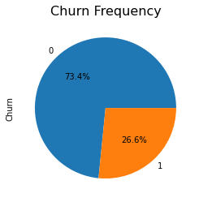

```python
df2["Churn"].value_counts().plot.pie(autopct = "%1.1f%%")
plt.title("Churn Frequency",fontsize=16)
```

Demographic Statistics

1)Gender

2)SeniorCitizen

3)Partner

4)Dependents

```python
#Gender vs Churn Distributions
df["Gender"].value_counts()
```

```
Male      3549
Female    3483
Name: Gender, dtype: int64
```

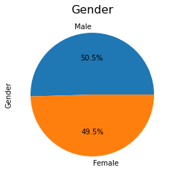

```python
df["Gender"].value_counts().plot.pie(autopct="%1.1f%%")
plt.title("Gender",fontsize=16)
```

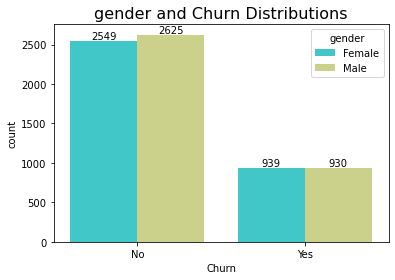

```python
ax=sns.countplot(x="Churn", data=data,hue="gender",palette="rainbow")
for i in ax.containers:
    ax.bar_label(i,)
plt.title("gender and Churn Distributions",fontsize=16)
```

*From the above charts we can observe that they are fairly equal number of Male and Female Customers.

*Churn percentage of both the genders are compartively equal.

```python
#Partner VS Churn Distributions
df["Partner"].value_counts()
```

```
No     3639
Yes    3393
Name: Partner, dtype: int64
```

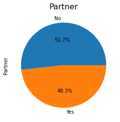

```python
df["Partner"].value_counts().plot.pie(autopct="%1.1f%%")
plt.title("Partner",fontsize=16)
```

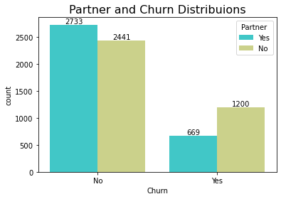

```python
ax=sns.countplot(x="Churn", data=data,hue="Partner",palette="rainbow")

for i in ax.containers:
    ax.bar_label(i,)
plt.title("Partner and Churn Distribuions",fontsize=16)
```

*From the above charts we can observe that they are fairly equal number of customers who have partner(48.3%) and Not(51.7%) .

*Churn percentage is very high during last month.

```python
#Dependents VS Churn Distributions
df["Dependents"].value_counts()
```

```
No     4933
Yes    2099
Name: Dependents, dtype: int64
```

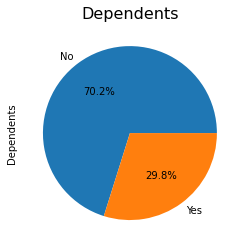

```python
df["Dependents"].value_counts().plot.pie(autopct="%1.1f%%")
plt.title("Dependents",fontsize=16)
```

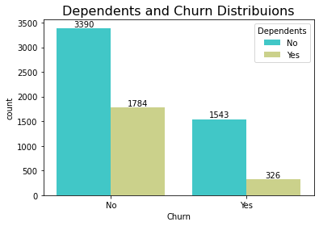

```python
ax=sns.countplot(x="Churn", data=data,hue="Dependents",palette="rainbow")
for i in ax.containers:
    ax.bar_label(i,)
plt.title("Dependents and Churn Distribuions",fontsize=16)
```

*From the above charts we can observe that their is only 30% of the customers have dependents.

*Churn percentage is very high during last month.

```python
#SeniorCitizen VS Churn Distributions
df["SeniorCitizen"].value_counts()
```

```
0    5890
1    1142
Name: SeniorCitizen, dtype: int64
```

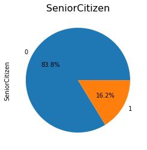

```python
df["SeniorCitizen"].value_counts().plot.pie(autopct="%1.1f%%")
plt.title("SeniorCitizen",fontsize=16)
```

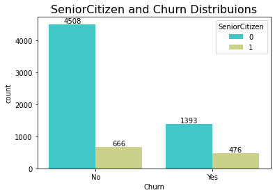

```python
ax=sns.countplot(x="Churn", data=data,hue="SeniorCitizen",palette="rainbow")
for i in ax.containers:
    ax.bar_label(i,)
plt.title("SeniorCitizen and Churn Distribuions",fontsize=16)
```

*From the above charts we can observe that their is only 16.2% of the customers are SeniorCitizen.

*Churn percentage is high during last month.

# Customer account information

1)Tenure

2)Contract

3)Payment Method

4)Paperless Billing

5)Monthly Charges

6)Total Charges

```python
#Contract VS Churn Distributions
df["Contract"].value_counts()
```

```
Month-to-month    3875
Two year          1685
One year          1472
Name: Contract, dtype: int64
```

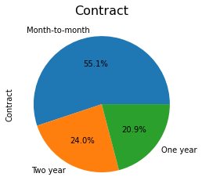

```python
df["Contract"].value_counts().plot.pie(autopct="%1.1f%%")
plt.title("Contract",fontsize=16)
```

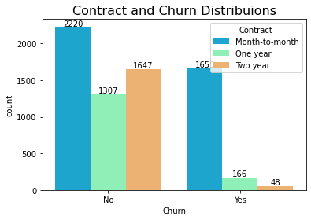

```python
ax=sns.countplot(x="Churn", data=data,hue="Contract",palette="rainbow")
for i in ax.containers:
    ax.bar_label(i,)
plt.title("Contract and Churn Distribuions",fontsize=16)
```

*From the above charts we can observe that people who have taken two year contract are likely to stay for longer.

```python
#PaperlessBilling VS Churn Distributions
df["PaperlessBilling"].value_counts()
```

```
Yes    4168
No     2864
Name: PaperlessBilling, dtype: int64
```

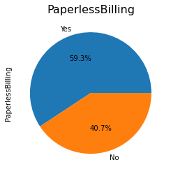

```python
df["PaperlessBilling"].value_counts().plot.pie(autopct="%1.1f%%")
plt.title("PaperlessBilling",fontsize=16)
```

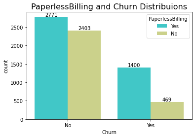

```python
ax=sns.countplot(x="Churn", data=data,hue="PaperlessBilling",palette="rainbow")
for i in ax.containers:
    ax.bar_label(i,)
plt.title("PaperlessBilling and Churn Distribuions",fontsize=16)
```

*Their churn percentage is also less compared to customer who have opted for paperlessbilling.

```python
#PaymentMethod VS Churn Distributions
df["PaymentMethod"].value_counts()
```

```
Electronic check             2365
Mailed check                 1604
Bank transfer (automatic)    1542
Credit card (automatic)      1521
Name: PaymentMethod, dtype: int64
```

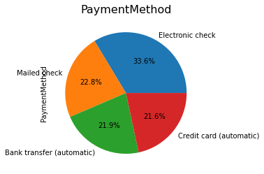

```python
df["PaymentMethod"].value_counts().plot.pie(autopct="%1.1f%%")
plt.title("PaymentMethod",fontsize=16)
```

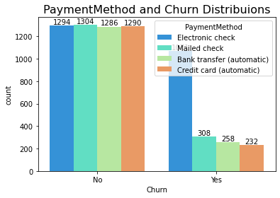

```python
ax=sns.countplot(x="Churn", data=data,hue="PaymentMethod",palette="rainbow")
for i in ax.containers:
    ax.bar_label(i,)
plt.title("PaymentMethod and Churn Distribuions",fontsize=16)
```

*From the above charts we can observe that nearly 33.6% customers have opted for Electronic check as payment modes.

*And churn percentage of customer who have opted for Electronic check are very high as compared to other payment modes.

```python
#Tenure VS Churn Distributions
df["Tenure"].value_counts()
```

```
1     613
72    362
2     238
3     200
4     176
     ...
38     59
28     57
39     56
44     51
36     50
Name: Tenure, Length: 72, dtype: int64
```

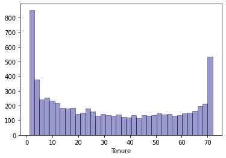

```python
ax = sns.distplot(df["Tenure"], hist=True, kde=False,
             bins=int(180/5), color = 'darkblue',
             hist_kws={'edgecolor':'black'},
             kde_kws={'linewidth': 4})
```

*From the above graph we can observe that customer who have taken higher contract are tend to stay for longer.

```python
#MonthlyCharges VS Churn Distributions
df["MonthlyCharges"].value_counts()
```

```
20.05     61
19.90     44
19.95     44
19.85     44
19.65     43
          ..
23.65      1
114.70     1
43.65      1
87.80      1
78.70      1
Name: MonthlyCharges, Length: 1584, dtype: int64
```

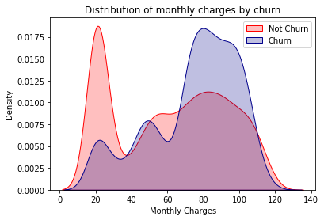

```python
ax = sns.kdeplot(df.MonthlyCharges[(df["Churn"] == 'No') ],
                color="Red", shade = True)
ax = sns.kdeplot(df.MonthlyCharges[(df["Churn"] == 'Yes') ],
                ax =ax, color="DarkBlue", shade= True)
ax.legend(["Not Churn","Churn"],loc='upper right')
ax.set_ylabel('Density')
ax.set_xlabel('Monthly Charges')
ax.set_title('Distribution of monthly charges by churn')
```

```python
#TotalCharges VS Churn Distributions
df["TotalCharges"].value_counts()
```

```
20.20      11
19.75       9
20.05       8
19.90       8
19.65       8
           ..
6849.40     1
692.35      1
130.15      1
3211.90     1
6844.50     1
Name: TotalCharges, Length: 6530, dtype: int64
```

```python
df.TotalCharges = pd.to_numeric(df.TotalCharges,errors="coerce")
```

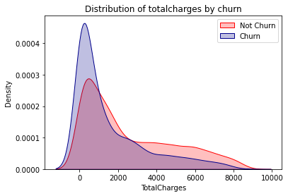

```python
ax = sns.kdeplot(df.TotalCharges[(df["Churn"] == 'No') ],
                color="Red", shade = True)
ax = sns.kdeplot(df.TotalCharges[(df["Churn"] == 'Yes') ],
                ax =ax, color="DarkBlue", shade= True)
ax.legend(["Not Churn","Churn"],loc='upper right')
ax.set_ylabel('Density')
ax.set_xlabel('TotalCharges')
ax.set_title('Distribution of totalcharges by churn')
```

*From the above graph we can observe that percentage of customer who have churned services because of Total charges is high

Services used by Customer 1)Phone Service

2)Multiple Lines

3)Internet Service

4)Online Security

5)Online Backup

6)Device Protection

7)Tech Support

8)Streaming TV

9)Streaming Movies

```python
#PhoneService VS Churn Distributions
df["PhoneService"].value_counts()
```

```
Yes    6352
No      680
Name: PhoneService, dtype: int64
```

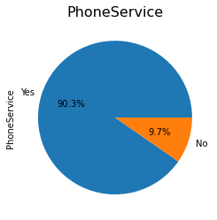

```python
df["PhoneService"].value_counts().plot.pie(autopct="%1.1f%%")
plt.title("PhoneService",fontsize=16)
```

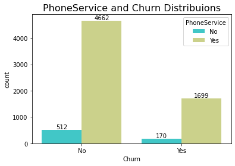

```python
ax=sns.countplot(x="Churn", data=data,hue="PhoneService",palette="rainbow")
for i in ax.containers:
    ax.bar_label(i,)
plt.title("PhoneService and Churn Distribuions",fontsize=16)
```

*There are nearly 90.3% of the customer have opted for PhoneService and churn percentage is very less

```python
#MultipleLines VS Churn Distributions
df["MultipleLines"].value_counts()
```

```
No                  3385
Yes                 2967
No phone service     680
Name: MultipleLines, dtype: int64
```

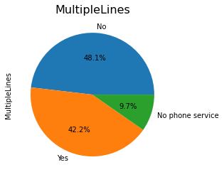

```python
df["MultipleLines"].value_counts().plot.pie(autopct="%1.1f%%")
plt.title("MultipleLines",fontsize=16)
```

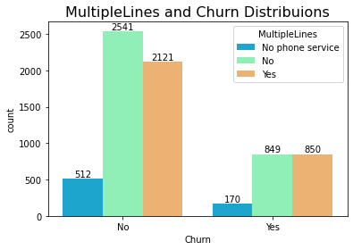

```python
ax=sns.countplot(x="Churn", data=data,hue="MultipleLines",palette="rainbow")
for i in ax.containers:
    ax.bar_label(i,)
plt.title("MultipleLines and Churn Distribuions",fontsize=16)
```

*There are fairly very less difference in number of customer who have opted and not opted for Multiple lines with no PhoneService.

*And their is no much difference in churn percentage.

```python
#InternetService VS Churn Distributions
df["InternetService"].value_counts()
```

```
Fiber optic    3096
DSL            2416
No             1520
Name: InternetService, dtype: int64
```

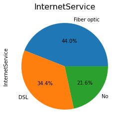

```python
df["InternetService"].value_counts().plot.pie(autopct="%1.1f%%")
plt.title("InternetService",fontsize=16)
```

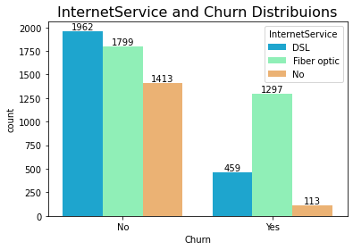

```python
ax=sns.countplot(x="Churn", data=data,hue="InternetService",palette="rainbow")
for i in ax.containers:
    ax.bar_label(i,)
plt.title("InternetService and Churn Distribuions",fontsize=16)
```

*Customer who have opted for Fiber optic is 44% and observed probability of churn percentage is very high compared to DSL.

*Customer who have opted for DSL is 34.4% and observed probability of churn percentage is very less compared to Fibre optics.

```python
#StreamingTV VS Churn Distributions
df["StreamingTV"].value_counts()
```

```
No                     2809
Yes                    2703
No internet service    1520
Name: StreamingTV, dtype: int64
```

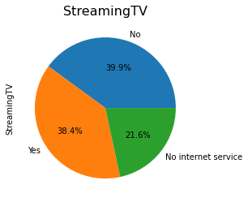

```python
df["StreamingTV"].value_counts().plot.pie(autopct="%1.1f%%")
plt.title("StreamingTV",fontsize=16)
```

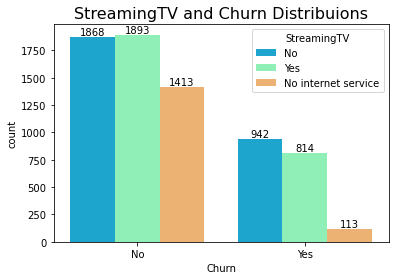

```python
ax=sns.countplot(x="Churn", data=data,hue="StreamingTV",palette="rainbow")
for i in ax.containers:
    ax.bar_label(i,)
plt.title("StreamingTV and Churn Distribuions",fontsize=16)
```

*And observed their is no much difference in churn percentage.

```python
#StreamingMovies VS Churn Distributions
df["StreamingMovies"].value_counts()
```

```
No                     2781
Yes                    2731
No internet service    1520
Name: StreamingMovies, dtype: int64
```

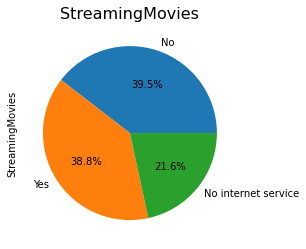

```python
df["StreamingMovies"].value_counts().plot.pie(autopct="%1.1f%%")
plt.title("StreamingMovies",fontsize=16)
```

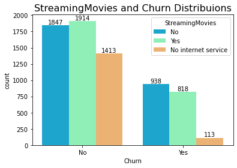

```python
ax=sns.countplot(x="Churn", data=data,hue="StreamingMovies",palette="rainbow")
for i in ax.containers:
    ax.bar_label(i,)
plt.title("StreamingMovies and Churn Distribuions",fontsize=16)
```

*There is fairly very less difference in number of customer who have opted(38.8%) and not opted(39.5%) for StreamingMovies services with no Internetservices.

*And observed their is no much difference in churn percentage.

```python
#TechSupport VS Churn Distributions
df["TechSupport"].value_counts()
```

```
No                     3472
Yes                    2040
No internet service    1520
Name: TechSupport, dtype: int64
```

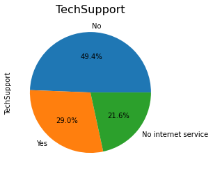

```python
df["TechSupport"].value_counts().plot.pie(autopct="%1.1f%%")
plt.title("TechSupport",fontsize=16)
```

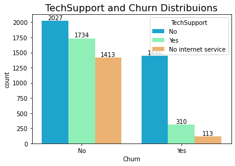

```python
ax=sns.countplot(x="Churn", data=data,hue="TechSupport",palette="rainbow")
for i in ax.containers:
    ax.bar_label(i,)
plt.title("TechSupport and Churn Distribuions",fontsize=16)
```

*From the above chart we can observe that their is nearly 29% of the customer have opted for TechSupport and churn percentage is also very less.

```python
#DeviceProtection VS Churn Distributions
df["DeviceProtection"].value_counts()
```

```
No                     3094
Yes                    2418
No internet service    1520
Name: DeviceProtection, dtype: int64
```